# 07_three_dim_dist

## 07_three_dim_dist

#### Question

1. A [right rectangular prism](https://en.m.wikipedia.org/wiki/Rectangular_cuboid) is 13 inches wide, 8 inches deep, and 11 inches tall.

   What is the distance between opposite corners?

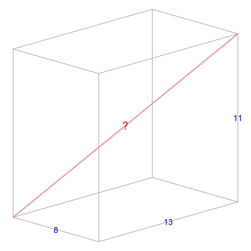

   Please be accurate within $\pm$ 0.01 of the exact answer.

#### Question

2. A [right rectangular prism](https://en.m.wikipedia.org/wiki/Rectangular_cuboid) is 5 inches wide, 6 inches deep, and 17 inches tall.

   What is the distance between opposite corners?

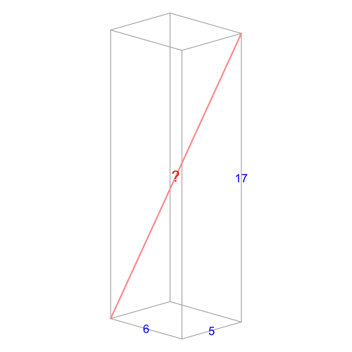

   Please be accurate within $\pm$ 0.01 of the exact answer.

#### Question

3. A [right rectangular prism](https://en.m.wikipedia.org/wiki/Rectangular_cuboid) is 11 inches wide, 15 inches deep, and 18 inches tall.

   What is the distance between opposite corners?

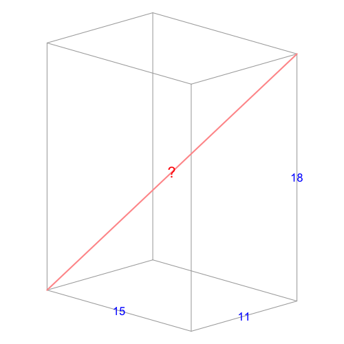

   Please be accurate within $\pm$ 0.01 of the exact answer.

#### Question

4. A [right rectangular prism](https://en.m.wikipedia.org/wiki/Rectangular_cuboid) is 6 inches wide, 15 inches deep, and 7 inches tall.

   What is the distance between opposite corners?

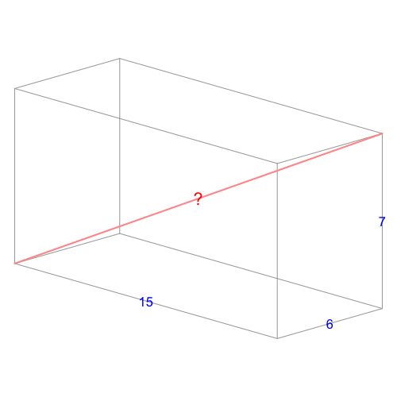

   Please be accurate within $\pm$ 0.01 of the exact answer.

#### Question

5. A [right rectangular prism](https://en.m.wikipedia.org/wiki/Rectangular_cuboid) is 5 inches wide, 9 inches deep, and 19 inches tall.

   What is the distance between opposite corners?

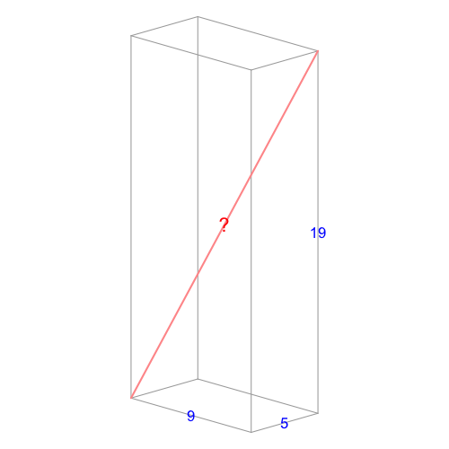

   Please be accurate within $\pm$ 0.01 of the exact answer.

#### Question

6. A [right rectangular prism](https://en.m.wikipedia.org/wiki/Rectangular_cuboid) is 14 inches wide, 10 inches deep, and 18 inches tall.

   What is the distance between opposite corners?

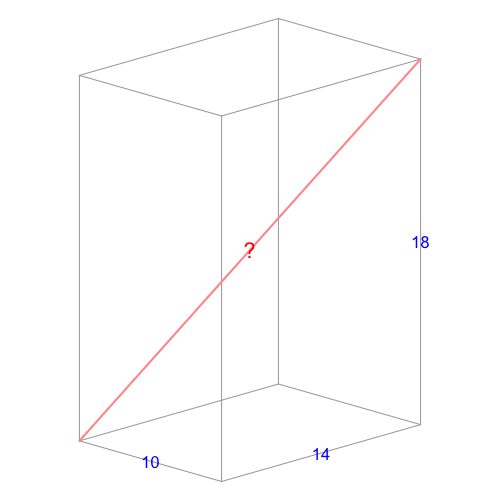

   Please be accurate within $\pm$ 0.01 of the exact answer.

#### Question

7. A [right rectangular prism](https://en.m.wikipedia.org/wiki/Rectangular_cuboid) is 14 inches wide, 11 inches deep, and 13 inches tall.

   What is the distance between opposite corners?

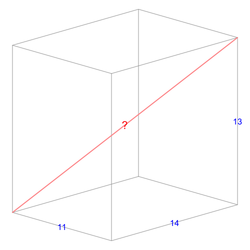

   Please be accurate within $\pm$ 0.01 of the exact answer.

#### Question

8. A [right rectangular prism](https://en.m.wikipedia.org/wiki/Rectangular_cuboid) is 19 inches wide, 9 inches deep, and 20 inches tall.

   What is the distance between opposite corners?

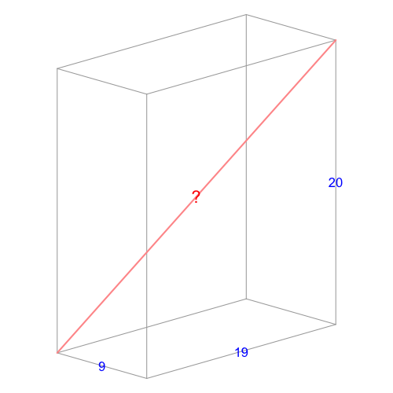

   Please be accurate within $\pm$ 0.01 of the exact answer.